# (*Stenella frontalis*)

General Info:

- There is well documented geographic variation in vocalizations, but vocalizations recorded near the Azores are generally similar to those in the offshore Western Atlantic (Gannier et al, 2020)
- Whistles are generally lower in fq and shorter in duration than common dolphin (Gannier et al, 2020)
- Whistles often have a high number of inflection points (Azevedo et al, 2010)
- Can be hard to tell apart from bottlenose dolphins

Clicks:

- ICI:
  - Weak modal ICI, possibly due to overlapping click trains (Frasier et al, 2017)
  - 0.075 sec (Frasier et al, 2017)
- Whistles:
  - Harmonics often present (Gannier et al, 2020)
  - Groups over the continental shelf are significantly different than those from offshore waters, with lower fq, shorter durations, fewer inflection points, and a greater number of steps (Baron et al, 2008)
- Frequency:
  - Avg minimal fq 7.3 kHz (Gannier et al, 2020)
  - Avg maximal fq > 16kHz (Gannier et al, 2020)
  - Range 7-16 kHz (Azevedo et al, 2010)
- Duration:
  - Avg 0.65 (Gannier et al, 2020)
  - Range 0.08-2.07 (Azevedo et al, 2010)
- Waveform:
  - Generally up swept, although up and down sweep modes are possible (Gannier et al, 2020)

Acoustic events from literature:

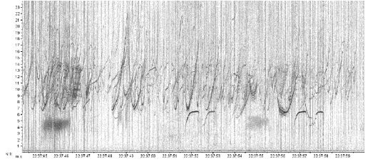

(Gannier et al, 2020)

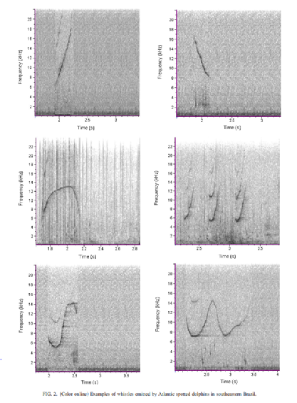

(Azevedo et al, 2010)

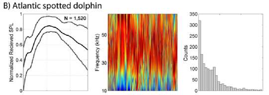

(Frasier et al, 2017)

Sources:

1. A. F. Azevedo, L. Flach, T. L. Bisi, L. G. Andrade, P. R. Dorneles and J. Lailson-Brito, The Journal of the Acoustical Society of America **127** (4), 2646-2451 (2010).
2. K. E. Frasier, M. A. Roch, M. S. Soldevilla, S. M. Wiggins, L. P. Garrison and J. A. Hildebrand, PLoS Computational Biology **13** (12), e1005823 (2017).
3. S. C. Baron, A. Martinez, L. P. Garrison and E. O. Keith, Marine Mammal Science **24** (1), 42-56 (2008).